# Programación para *Data Science*

## Visualización de datos en Python

## Ejercicios para la PEC

A continuación encontraréis los **ejercicios y preguntas teóricas que debe completar en esta PEC** y que forman parte de la evaluación de esta unidad.

### Ejercicio 1

Pokemon es una saga RPG muy famosa a nivel mundial. La misión de estos juegos es capturar y entrenar a los pokemon, unas criaturas que habitan en todo el continente, para hacerse con el título de maestro de la liga Pokemon. Los Pokemons son criaturas muy diversas, hay muchos tipos diferentes y algunos de ellos pueden evolucionar.

1. ¿Cuántos Pokemons legendarios hay? Cuántos Pokemons hay de cada tipo de evolución (*variable Stage*)?
2. ¿Cuál es el tipo más frecuente? Y el menos?
3. Un nuevo entrenador tiene que escoger entre 3 Pokemons iniciales (Bulbasaur, Charmander y Squirtle) y nos ha pedido que le ayudemos a decidir basándonos en las estadísticas de los pokemons de estos tres tipos (Grass, Fire y Water) . Si nos centramos sólo en las características de ataque y defensa, qué tipo deberíamos recomendar?

**Representa las respuestas gráficamente.**

Pista: podéis utilizar la función jointplot que hemos visto en el Notebook de teoría. Considerad qué tipo de gráfica, de entre las que ofrece jointplot, se ajusta a los requerimientos del enunciado.

**(2.5 puntos)**

[figure not shown]

```python
# Respuesta

import pandas as pd
import matplotlib.pyplot as plt

#Cargo los datos
datos=pd.read_csv("data/Pokemon.csv")

#1.1 Número de pokemons legendarios:

import seaborn as sns
sns.set(style="darkgrid")

f, axes = plt.subplots(1, 3,figsize=(23,6))

ax = sns.countplot(x="Legendary", data=datos, color="steelblue", ax=axes[0]) #grafico los datos de la columna Legendary
ax.set_ylabel('Cantidad') #cambio el label del eje y
ax.set_xlabel("") #dejo vacio el label del eje x
ax.set_title("1.1. Número de pokemons legendarios/no legendarios")
ax.set_xticklabels(["No legendario","Legendario"], rotation='horizontal', fontsize=10) #cambio los labels de las
                                                                                       #categorias del eje x.

#1.2 Número de pokemons en cada clase:

import seaborn as sns
sns.set(style="darkgrid")

ax = sns.countplot(x="Stage", data=datos, color="steelblue",ax=axes[1]) #grafico los datos de la columna Stage
ax.set_ylabel('Cantidad') #cambio el label del eje y
ax.set_xlabel("") #dejo vacio el label del eje x
ax.set_title("1.2. Número de pokemons por clase")
_=ax.set_xticklabels(["Clase 1","Clase 2","Clase 3"], rotation='horizontal', fontsize=10) #cambio los labels de las
                                                                                       #categorias del eje x.

#2. Tipo màs frecuente

import seaborn as sns
sns.set(style="darkgrid")

ax = sns.countplot(x="Type 1", data=datos,color="steelblue", ax=axes[2]) #grafico los datos de la columna Stage
ax.set_ylabel('Cantidad') #cambio el label del eje y
ax.set_xlabel("") #dejo vacio el label del eje x
ax.set_title("2. Número de pokemons por tipo")
tipos=list(set(datos["Type 1"]))
_=ax.set_xticklabels(tipos, rotation=45, fontsize=10) #cambio los labels de las categorias del eje x.
```

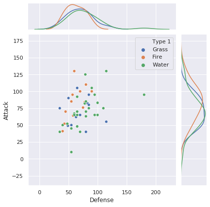

```python
#3.
#Creo una nueva data frame con los datos de los tipos mencionados en el enunciado
df=datos.loc[(datos["Type 1"]=="Grass")|(datos["Type 1"]=="Fire")|(datos["Type 1"]=="Water")]

import seaborn as sns

#Este mètodo para graficar lo obtuve de: https://stackoverflow.com/questions/55839345/seaborn-jointplot-group-colour-coding-for-both-scatter-and-density-plots
grid = sns.JointGrid(x='Defense', y='Attack', data=df)

#creo el scatterplot
g = grid.plot_joint(sns.scatterplot, hue='Type 1', data=df)

#agrego los density plots
sns.kdeplot(df.loc[df['Type 1']=='Grass', 'Defense'], ax=g.ax_marg_x, legend=False)
sns.kdeplot(df.loc[df['Type 1']=='Fire', 'Defense'], ax=g.ax_marg_x, legend=False)
sns.kdeplot(df.loc[df['Type 1']=='Water', 'Defense'], ax=g.ax_marg_x, legend=False)
sns.kdeplot(df.loc[df['Type 1']=='Grass', 'Attack'], ax=g.ax_marg_y, vertical=True, legend=False)
sns.kdeplot(df.loc[df['Type 1']=='Fire', 'Attack'], ax=g.ax_marg_y, vertical=True, legend=False)
_:sns.kdeplot(df.loc[df['Type 1']=='Water', 'Attack'], ax=g.ax_marg_y, vertical=True, legend=False)

#En base a las dos variables analizadas recomendarìa el tipo fuego ya que tiene una media de ataque bastante meyor al resto mientras que no difiere demasiado con el resto en cuando a defensa.
```

### Exercicio 2

La ciudad de Barcelona está realizando un estudio para ampliar las áreas verdes de la ciudad. Es por ello que el ayuntamiento de Barcelona requiere de nuestro servicio para construir un mapa **interactivo** que muestre los puntos donde hay árboles y palmeras en la ciudad.

Nota 1: Puede obtener los datos del arbolado de zona de la ciudad de Barcelona en el portal [Open Data BCN](https://opendata-ajuntament.barcelona.cat/data/es/dataset) y [cargar los datos](https://github.com/andrea-cuttone/geoplotlib/wiki/user-Guide#loading-data) a partir de un diccionario o un dataframe. Sino también puede cargar el conjunto de datos `arbrat_zona.csv` **(que os proporcionamos junto con el enunciado de la PEC)**.

Nota 2: Es importante que los tipos diferentes de zonas (arbol o palmera) tengan distinto color en el mapa.

**(2.5 puntos)**

```python
# Respuesta

# Importamos las librerías
import pandas as pd
import geoplotlib

#Cargo los datos y creo un data frame de pandas
data= pd.read_csv("data/arbrat_zona.csv")

#renombro las columnas a lat y lon
data=data.rename(columns={"LATITUD_WGS84": "lat", "LONGITUD_WGS84": "lon"})

#creo una base para arboles y otra para palmeras
arboles=data[data["TIPUS_ELEMENT"]=="ARBRE ZONA"]
palmeras=data[data["TIPUS_ELEMENT"]=="PALMERA ZONA"]

#convierto los DataFrame a DataAccessObject de geoplitlib
arboles=geoplotlib.utils.DataAccessObject.from_dataframe(arboles)
palmeras=geoplotlib.utils.DataAccessObject.from_dataframe(palmeras)

#muestro los puntos con diferente color
geoplotlib.dot(arboles, color='b', point_size=1.5)
geoplotlib.dot(palmeras, color='r', point_size=1.5)

#muestro el mapa interactivo
geoplotlib.show()
```

### Ejercicio 3

1. ¿Cuántos árboles y cuántas palmeras han plantado cada año? **Ver resultados separados para cada grupo (árbol y palmera).**
2. Adicionalmente, se nos pide generar una gráfica que muestre la **distribución** de los meses en los que se han plantado árboles y palmeras en los últimos 3 años (de 2017 2019).

Nota 1: La columna con la información de la fecha de plantación tiene missing. Por lo tanto, se deben seleccionar sólo aquellas filas con este dato.

Nota 2: Para obtener la información del mes y año a partir de la fecha, puede utilizar la función *DatetimeIndex* de la librería pandas.

Nota 3: La visualización de los datos debería ser atractiva y clara a fin de que los responsables del ayuntamiento puedan sacar conclusiones de ellas.

**(2.5 puntos)**

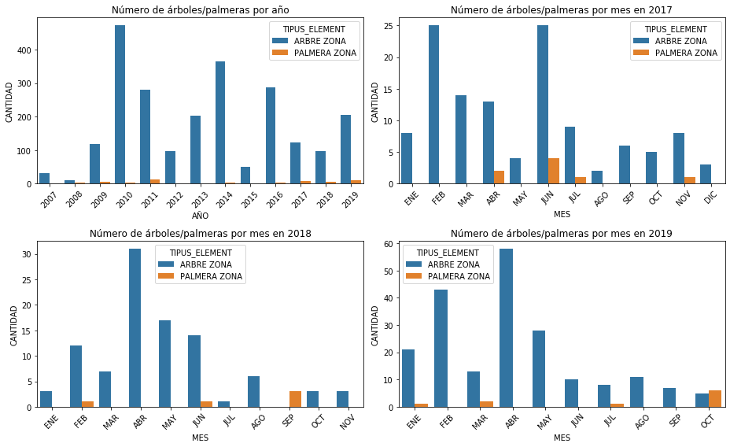

```python
# Respuesta
import pandas as pd
import seaborn as sns
import matplotlib.pyplot as plt

#creo un nuevo data frame eliminando las filas donde haya "NaN" para la columna "DATA_PLANTACIO".
#Obtuve un warning e investigando (fuente: https://www.dataquest.io/blog/settingwithcopywarning/)
#descubrì que agregando ".copy()" se solucionaba el problema.
df=data.dropna(subset=["DATA_PLANTACIO"]).copy()
df["AÑO"] = pd.DatetimeIndex(df["DATA_PLANTACIO"]).year #creo una nueva columna con el dato año
df["MES"]= pd.DatetimeIndex(df["DATA_PLANTACIO"]).month #creo una nueva columna con el dato mes

#Ajusto los parámetros para los gráficos
f, axes = plt.subplots(2, 2,figsize=(13,8))

#1. utilizo countplot de seaborn para graficar los datos
ax=sns.countplot(x="AÑO", hue="TIPUS_ELEMENT", data=df, ax=axes[0,0])
ax.set_ylabel("CANTIDAD")
ax.set_title("Número de árboles/palmeras por año")
_=ax.set_xticklabels(sorted(set(df["AÑO"])), rotation=45, fontsize=10)


#2.
#creo una nueva DF con los datos correspondientes a los años solicitados
df_2=df.loc[(df.AÑO==2017)|(df.AÑO==2018)|(df.AÑO==2019)]

#hago un gráfico con el número de árboles y palmeras por mes, para cada uno de los años solicitados
#2017
ax=sns.countplot(x="MES", hue="TIPUS_ELEMENT", data=df_2[df_2["AÑO"]==2017],ax=axes[0,1])
ax.set_ylabel("CANTIDAD")
ax.set_title("Número de árboles/palmeras por mes en 2017")
meses=["ENE","FEB","MAR","ABR","MAY","JUN","JUL","AGO","SEP","OCT","NOV","DIC"]
ax=ax.set_xticklabels(meses, rotation=45, fontsize=10)
#ax=plt.legend(loc='upper right')

#2018
ax=sns.countplot(x="MES", hue="TIPUS_ELEMENT", data=df_2[df_2["AÑO"]==2018],ax=axes[1,0])
ax.set_ylabel("CANTIDAD")
ax.set_title("Número de árboles/palmeras por mes en 2018")
meses=["ENE","FEB","MAR","ABR","MAY","JUN","JUL","AGO","SEP","OCT","NOV","DIC"]
ax=ax.set_xticklabels(meses, rotation=45, fontsize=10)

#2019
ax=sns.countplot(x="MES", hue="TIPUS_ELEMENT", data=df_2[df_2["AÑO"]==2019],ax=axes[1,1])
ax.set_ylabel("CANTIDAD")
ax.set_title("Número de árboles/palmeras por mes en 2019")
meses=["ENE","FEB","MAR","ABR","MAY","JUN","JUL","AGO","SEP","OCT","NOV","DIC"]
ax=ax.set_xticklabels(meses, rotation=45, fontsize=10)
#ax=plt.legend(loc='upper right')

f.tight_layout()
```